# Final Project

James Livingstone

December 15, 2022

# Summary Statistics

```r
heart %>%
  select(age, cigsPerDay, totChol, sysBP, diaBP, BMI, heartRate, glucose) %>%
  descr(stats = "common", transpose = T)
```

```
## Descriptive Statistics
## heart
## N: 864
##
##                      Mean   Std.Dev      Min   Median      Max   N.Valid   Pct.Valid
## ---------------- -------- --------- -------- -------- -------- --------- -----------
##              age    51.48      8.65    33.00    52.00    70.00    864.00      100.00
##              BMI    26.04      4.19    15.96    25.69    56.80    864.00      100.00
##       cigsPerDay     9.33     11.98     0.00     0.00    50.00    864.00      100.00
##            diaBP    84.82     13.34    48.00    83.00   140.00    864.00      100.00
##          glucose    84.72     33.07    45.00    78.00   394.00    864.00      100.00
##        heartRate    75.88     12.16    44.00    75.00   120.00    864.00      100.00
##            sysBP   137.17     25.15    83.50   132.00   295.00    864.00      100.00
##          totChol   240.82     44.87   124.00   238.00   464.00    864.00      100.00
```

```r
heart %>%
  select(male, education, currentSmoker, BPMeds, prevalentStroke, prevalentHyp, diabetes, TenYearCHD) %>%
  freq(stats = "common", transpose = T)
```

```
## Frequencies
## heart$male
## Type: Integer
##
##               Freq   % Valid   % Valid Cum.   % Total   % Total Cum.
## ----------- ------ --------- -------------- --------- --------------
##           0    437     50.58          50.58     50.58          50.58
##           1    427     49.42         100.00     49.42         100.00
##        <NA>      0                               0.00         100.00
##       Total    864    100.00         100.00    100.00         100.00
##
## heart$education
## Type: Integer
##
##               Freq   % Valid   % Valid Cum.   % Total   % Total Cum.
## ----------- ------ --------- -------------- --------- --------------
##           1    393     45.49          45.49     45.49          45.49
##           2    242     28.01          73.50     28.01          73.50
##           3    127     14.70          88.19     14.70          88.19
##           4    102     11.81         100.00     11.81         100.00
##        <NA>      0                               0.00         100.00
##       Total    864    100.00         100.00    100.00         100.00
##
## heart$currentSmoker
## Type: Integer
##
##               Freq   % Valid   % Valid Cum.   % Total   % Total Cum.
## ----------- ------ --------- -------------- --------- --------------
##           0    438     50.69          50.69     50.69          50.69
##           1    426     49.31         100.00     49.31         100.00
##        <NA>      0                               0.00         100.00
##       Total    864    100.00         100.00    100.00         100.00
##
## heart$BPMeds
## Type: Integer
##
##               Freq   % Valid   % Valid Cum.   % Total   % Total Cum.
## ----------- ------ --------- -------------- --------- --------------
##           0    829     95.95          95.95     95.95          95.95
##           1     35      4.05         100.00      4.05         100.00
```

[output cut: 27 more lines]

```
## ----------- ------ --------- -------------- --------- --------------
##           0    826     95.60          95.60     95.60          95.60
##           1     38      4.40         100.00      4.40         100.00
##        <NA>      0                               0.00         100.00
##       Total    864    100.00         100.00    100.00         100.00
##
## heart$TenYearCHD
## Type: Integer
##
##               Freq   % Valid   % Valid Cum.   % Total   % Total Cum.
## ----------- ------ --------- -------------- --------- --------------
##           0    440     50.93          50.93     50.93          50.93
##           1    424     49.07         100.00     49.07         100.00
##        <NA>      0                               0.00         100.00
##       Total    864    100.00         100.00    100.00         100.00
```

# First Model

```r
main_effect_model = glm(TenYearCHD ~ .-ID,family = binomial, data = heart)
summary(main_effect_model)
```

```
##
## Call:
## glm(formula = TenYearCHD ~ . - ID, family = binomial, data = heart)
##
## Deviance Residuals:
##     Min       1Q   Median       3Q      Max
## -2.2390  -0.9744  -0.5114   1.0279   2.1355
##
## Coefficients:
##                   Estimate Std. Error z value Pr(>|z|)
## (Intercept)      -5.676982   1.076462  -5.274 1.34e-07 ***
## male              0.423414   0.163474   2.590  0.00959 **
## age               0.065591   0.010236   6.408 1.48e-10 ***
## education        -0.032054   0.073962  -0.433  0.66474
## currentSmoker     0.077009   0.251567   0.306  0.75952
## cigsPerDay        0.024284   0.010689   2.272  0.02309 *
## BPMeds            0.810429   0.496609   1.632  0.10270
## prevalentStroke  14.839053 474.249558   0.031  0.97504
## prevalentHyp      0.508757   0.222185   2.290  0.02203 *
## diabetes         -0.164727   0.547823  -0.301  0.76365
## totChol           0.001310   0.001770   0.740  0.45930
## sysBP             0.014464   0.006227   2.323  0.02019 *
## diaBP            -0.009272   0.010305  -0.900  0.36827
## BMI               0.001617   0.020267   0.080  0.93642
## heartRate        -0.005933   0.006581  -0.902  0.36728
## glucose           0.006220   0.003863   1.610  0.10739
## ---
## Signif. codes:  0 '***' 0.001 '**' 0.01 '*' 0.05 '.' 0.1 ' ' 1
##
## (Dispersion parameter for binomial family taken to be 1)
##
##     Null deviance: 1197.5  on 863  degrees of freedom
## Residual deviance: 1022.4  on 848  degrees of freedom
## AIC: 1054.4
##
## Number of Fisher Scoring iterations: 14
```

Good-Fit Test

```r
1 - pchisq(main_effect_model$null.deviance - main_effect_model$deviance, main_effect_model$df.null - main_effect_model$df.residual)
```

```
## [1] 0
```

# VIF

```r
vif(main_effect_model)
```

```
##            male             age       education   currentSmoker      cigsPerDay
##        1.174635        1.245915        1.053684        2.783381        2.911536
##          BPMeds prevalentStroke    prevalentHyp        diabetes         totChol
##        1.067498        1.000000        1.985439        1.867119        1.087225
##           sysBP           diaBP             BMI       heartRate         glucose
##        3.525080        3.080173        1.227433        1.108924        1.875248
```

```r
# no collinearity, all VIFs are under 5
```

There is no collinearity amongst the independent variables; all of the vif values are under 5.

Step-Wise

```r
intercept_only = glm(TenYearCHD ~ 1, family = binomial, data = heart)
step(intercept_only, formula(main_effect_model),trace = 0)
```

```
##
## Call:  glm(formula = TenYearCHD ~ age + sysBP + cigsPerDay + prevalentStroke +
##     male + prevalentHyp + glucose + BPMeds, family = binomial,
##     data = heart)
##
## Coefficients:
##     (Intercept)              age            sysBP       cigsPerDay
##       -6.195265         0.068758         0.010956         0.026640
## prevalentStroke             male     prevalentHyp          glucose
##       14.785024         0.397370         0.440520         0.005527
##          BPMeds
##        0.831589
##
## Degrees of Freedom: 863 Total (i.e. Null);  855 Residual
## Null Deviance:       1197
## Residual Deviance: 1025  AIC: 1043
```

```r
#step-wise removed education, currentSmoker, diabetes, totChol, diaBP,BMI and heartRate from the model

main_effect_model2 = glm(TenYearCHD ~ age + sysBP + cigsPerDay + prevalentStroke + male + prevalentHyp + glucose + BPMeds, family = binomial, data = heart)
```

# Linearity

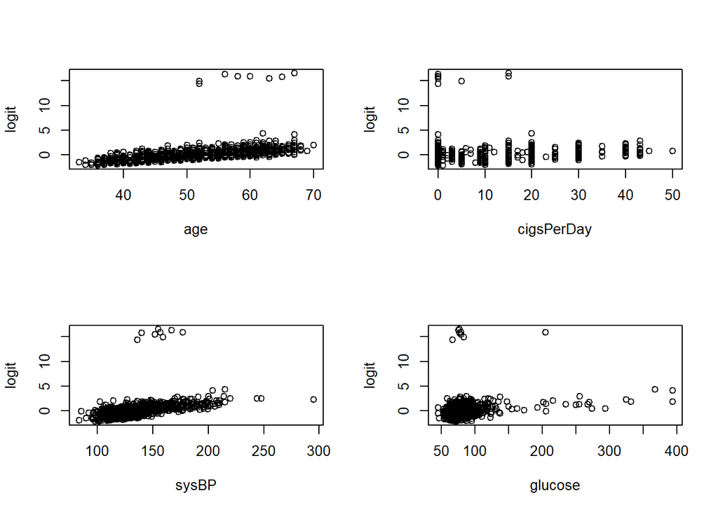

```r
heart2 = heart %>%
  mutate(probs = predict(main_effect_model2, type = "response"),
         logit = log(probs / (1 - probs)))

# check for linearity of logit vs. quantitative predictors
par(mfrow = c(2, 2))
plot(logit ~ age, data = heart2)
plot(logit ~ cigsPerDay, data = heart2)
plot(logit ~ sysBP, data = heart2)
plot(logit ~ glucose, data = heart2)
```

```r
#all plots look linear
```

Significant Interactions

```r
model4 = glm(TenYearCHD ~ age + sysBP + cigsPerDay + prevalentStroke + male + prevalentHyp + glucose + BPMeds + age * male, family = binomial, data = heart)
summary(model4) #significant
```

```
##
## Call:
## glm(formula = TenYearCHD ~ age + sysBP + cigsPerDay + prevalentStroke +
##     male + prevalentHyp + glucose + BPMeds + age * male, family = binomial,
##     data = heart)
##
## Deviance Residuals:
##     Min       1Q   Median       3Q      Max
## -2.2486  -0.9580  -0.5512   1.0138   2.0419
##
## Coefficients:
##                   Estimate Std. Error z value Pr(>|z|)
## (Intercept)      -5.333555   0.837374  -6.369 1.90e-10 ***
## age               0.049663   0.013603   3.651 0.000261 ***
## sysBP             0.011979   0.004633   2.586 0.009721 **
## cigsPerDay        0.027441   0.006945   3.951 7.78e-05 ***
## prevalentStroke  14.746917 475.255950   0.031 0.975246
## male             -1.543098   0.988923  -1.560 0.118670
## prevalentHyp      0.458533   0.216287   2.120 0.034004 *
## glucose           0.005376   0.002841   1.892 0.058431 .
## BPMeds            0.838834   0.492216   1.704 0.088344 .
## age:male          0.037550   0.018911   1.986 0.047075 *
## ---
## Signif. codes:  0 '***' 0.001 '**' 0.01 '*' 0.05 '.' 0.1 ' ' 1
##
## (Dispersion parameter for binomial family taken to be 1)
##
##     Null deviance: 1197.5  on 863  degrees of freedom
## Residual deviance: 1021.0  on 854  degrees of freedom
## AIC: 1041
##
## Number of Fisher Scoring iterations: 14
```

```r
final_model = glm(TenYearCHD ~ age + sysBP + cigsPerDay + prevalentStroke + male + prevalentHyp + glucose + BPMeds + age * male, family = binomial, data = heart)
summary(final_model)
```

```
##
## Call:
## glm(formula = TenYearCHD ~ age + sysBP + cigsPerDay + prevalentStroke +
##     male + prevalentHyp + glucose + BPMeds + age * male, family = binomial,
##     data = heart)
##
## Deviance Residuals:
##     Min       1Q   Median       3Q      Max
## -2.2486  -0.9580  -0.5512   1.0138   2.0419
##
## Coefficients:
##                   Estimate Std. Error z value Pr(>|z|)
## (Intercept)      -5.333555   0.837374  -6.369 1.90e-10 ***
## age               0.049663   0.013603   3.651 0.000261 ***
## sysBP             0.011979   0.004633   2.586 0.009721 **
## cigsPerDay        0.027441   0.006945   3.951 7.78e-05 ***
## prevalentStroke  14.746917 475.255950   0.031 0.975246
## male             -1.543098   0.988923  -1.560 0.118670
## prevalentHyp      0.458533   0.216287   2.120 0.034004 *
## glucose           0.005376   0.002841   1.892 0.058431 .
## BPMeds            0.838834   0.492216   1.704 0.088344 .
## age:male          0.037550   0.018911   1.986 0.047075 *
## ---
## Signif. codes:  0 '***' 0.001 '**' 0.01 '*' 0.05 '.' 0.1 ' ' 1
##
## (Dispersion parameter for binomial family taken to be 1)
##
##     Null deviance: 1197.5  on 863  degrees of freedom
## Residual deviance: 1021.0  on 854  degrees of freedom
## AIC: 1041
##
## Number of Fisher Scoring iterations: 14
```

The first thing I did was run vif(model) to see check for collinearity; all of the VIF values were under 5 so there was no evidence of collinearity. Next I used step-wise to create a model with the lowest AIC score and in turn eliminate some variables. Step-wise removed education, currentSmoker, diabetes, totChol, diaBP,BMI and heartRate from the model. My current model now consisted of age, sysBP, cigsPerDay, prevalentStroke, male, prevalentHyp, glucose, and BPMeds. I then ran several models to check for interactions. I ran over two dozen interactions, the only interaction that displayed significance was age:male. My final model consists of this one interaction between age * male, and my AIC level is 1041 . Finally I checked for influential points and found there to be none.

logit(TenYearCHD) = -5.333555 + 0.049663age + 0.011979sysBP + 0.027441cigsPerDay + 14.746917prevalentStroke - 1.543098male + 0.458533prevalentHyp + 0.005376glucose + 0.838834BPMeds + 0.037550(age * male)

Influential Points

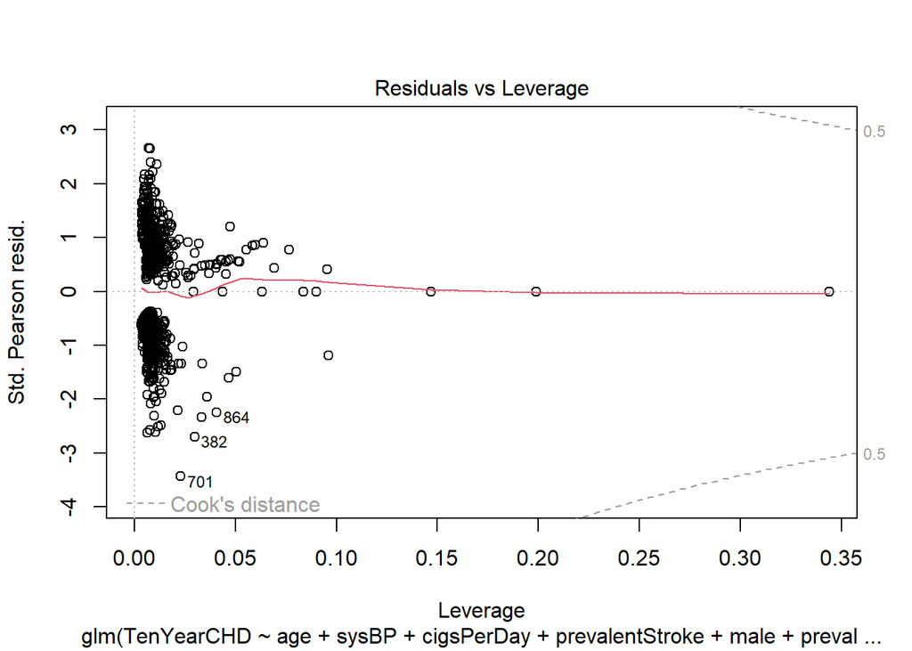

```r
# check influential points
plot(final_model, which = 5) #no influential points
```

[output not shown]